# DACSS-603: Final Project

Author

Michele Carlin

# Research Question

Much research has been done in the area of substance abuse treatment and the factors that may or may not predict successful completion of the treatment plan. Many factors, such as gender, sex, race/ethnicity, employment and various other factors have shown to be effective in predicting success. In this study, however, I will investigate whether one type of referral (self/family referral, healthcare provider, school, employer, etc.) predicts success better than others. Does self/family referral indicate that a person has accepted they have an addiction problem and therefore is more committed to the treatment vs. if a healthcare provider or an employer suggests treatment? Success in this study will be determined by the reason for discharge (1=completion of treatment, 0=all other reasons for discharge (e.g., left against professional advice, terminated by facility, incarcerated, and death)).

# Hypothesis

The null hypothesis states there is no statistically significant relationship between completion success and source of referral when controlling for gender, marital status, and employment status at time of admission.

The alternative hypothesis states that source of referral has a statistically significant relationship with completion success.

# Descriptive Statistics

The Substance Abuse and Mental Health Services Administration (SAMHSA) is an agency within the U.S. Department of Health and Human Services that leads public health efforts to advance the behavioral health of the nation. SAMHSA collects national data on an annual basis regarding admissions and discharges from substance abuse treatment facilities. Individual substance abuse facilities report out on the number of admissions/discharges they had within the prior year, as well as various pieces of information on each patient, to their state substance abuse agency, who then submits annual data to SAMHSA. For this project, I will be using the 2020 Treatment Episode Data Set on Discharges (TEDS-D).

# Read in file

```r
library(readr)
teds <- read_csv("tedsd_puf_2020.csv")
head(teds)
```

```
# A tibble: 6 × 76
  DISYR  CASEID STFIPS CBSA2010  EDUC MARSTAT SERVICES DETCRIM   LOS PSOURCE
  <dbl>   <dbl>  <dbl>    <dbl> <dbl>   <dbl>    <dbl>   <dbl> <dbl>   <dbl>
1  2020 1243074      2       -9     3       1        7      -9    35       1
2  2020 1168758      2       -9     3       2        7      -9    29       1
3  2020 1150846      2       -9     1       1        7      -9    36       1
4  2020 1121864      2       -9     3       2        7      -9    37       1
5  2020 1180820      2       -9     3       2        7      -9    36       1
6  2020 1312442      2       -9     3       1        7      -9    35       6
# ℹ 66 more variables: NOPRIOR <dbl>, ARRESTS <dbl>, EMPLOY <dbl>,
#   METHUSE <dbl>, PSYPROB <dbl>, PREG <dbl>, GENDER <dbl>, VET <dbl>,
#   LIVARAG <dbl>, DAYWAIT <dbl>, SERVICES_D <dbl>, REASON <dbl>,
#   EMPLOY_D <dbl>, LIVARAG_D <dbl>, ARRESTS_D <dbl>, DSMCRIT <dbl>, AGE <dbl>,
#   RACE <dbl>, ETHNIC <dbl>, DETNLF <dbl>, DETNLF_D <dbl>, PRIMINC <dbl>,
#   SUB1 <dbl>, SUB2 <dbl>, SUB3 <dbl>, SUB1_D <dbl>, SUB2_D <dbl>,
#   SUB3_D <dbl>, ROUTE1 <dbl>, ROUTE2 <dbl>, ROUTE3 <dbl>, FREQ1 <dbl>, …
```

# Dataframe details

# Created new dataframe with only selected variables

For my project, I will be focusing on the following variables: GENDER: this field contains biological sex (1=male, 2=female, -9=missing/unknown/not collected/invalid).

MARSTAT: Marital status (1=never married, 2=now married, 3=separated, 4=divorced or widowed, -9=missing/unknown/not collected/invalid)

EMPLOY: Employment status at time of admission (1=full-time, 2=part-time, 3=unemployed, 4=not in labor force, -9=missing/unknown/not collected/invalid)

PSOURCE: Referral source (1=individual/family member, 2=alcohol/drug use care provider, 3=other health care provider, 4=school, 5=employer, 6=other community referral, 7=court/criminal justice referral, -9=missing/unknown/not collected/invalid)

REASON: Reason for discharge (1=treatment completed, 2=dropped out of treatment, 3=terminated by facility, 4=transferred to another facility, 5=incarcerated, 6=death, 7=other)

# Create new dataframe with fewer variables

```r
library(tidyverse)
teds1 <-  select(teds, "CASEID", "GENDER", "MARSTAT", "EMPLOY", "REASON", "PSOURCE")
str(teds1)
```

```
tibble [1,391,393 × 6] (S3: tbl_df/tbl/data.frame)
 $ CASEID : num [1:1391393] 1243074 1168758 1150846 1121864 1180820 ...
 $ GENDER : num [1:1391393] 2 2 2 2 2 2 2 2 2 2 ...
 $ MARSTAT: num [1:1391393] 1 2 1 2 2 1 1 2 1 4 ...
 $ EMPLOY : num [1:1391393] 1 1 4 3 2 4 1 1 1 1 ...
 $ REASON : num [1:1391393] 3 1 7 3 3 3 3 3 3 3 ...
 $ PSOURCE: num [1:1391393] 1 1 1 1 1 6 1 1 1 1 ...
```

# EXPLORATORY DATA ANALYSIS

# All missing/unknown/not collected/invalid datapoints are coded as -9, therefore I am going to replace all -9’s with NA

```r
teds1$GENDER[teds1$GENDER == -9] <- NA
teds1$MARSTAT[teds1$MARSTAT == -9] <- NA
teds1$EMPLOY[teds1$EMPLOY == -9] <- NA
teds1$REASON[teds1$REASON == -9] <- NA
teds1$PSOURCE[teds1$PSOURCE == -9] <- NA
str(teds1)
```

```
tibble [1,391,393 × 6] (S3: tbl_df/tbl/data.frame)
 $ CASEID : num [1:1391393] 1243074 1168758 1150846 1121864 1180820 ...
 $ GENDER : num [1:1391393] 2 2 2 2 2 2 2 2 2 2 ...
 $ MARSTAT: num [1:1391393] 1 2 1 2 2 1 1 2 1 4 ...
 $ EMPLOY : num [1:1391393] 1 1 4 3 2 4 1 1 1 1 ...
 $ REASON : num [1:1391393] 3 1 7 3 3 3 3 3 3 3 ...
 $ PSOURCE: num [1:1391393] 1 1 1 1 1 6 1 1 1 1 ...
```

# Run counts/percents for each variable to see what percent of each variable is missing

```r
library(janitor)
tabyl(teds1$GENDER, sort = TRUE)
```

```
 teds1$GENDER      n      percent valid_percent
            1 896332 0.6441975775     0.6444899
            2 494430 0.3553489201     0.3555101
           NA    631 0.0004535024            NA
```

```r
tabyl(teds1$MARSTAT, sort = TRUE)
```

```
 teds1$MARSTAT      n    percent valid_percent
             1 718324 0.51626248    0.66608496
             2 135852 0.09763740    0.12597237
             3  61224 0.04400195    0.05677158
             4 163027 0.11716819    0.15117110
            NA 312966 0.22492998            NA
```

```r
tabyl(teds1$EMPLOY, sort = TRUE)
```

```
 teds1$EMPLOY      n    percent valid_percent
            1 210578 0.15134329    0.17193943
            2  81684 0.05870663    0.06669595
            3 535314 0.38473242    0.43709021
            4 397146 0.28543050    0.32427441
           NA 166671 0.11978715            NA
```

```r
tabyl(teds1$REASON, sort = TRUE)
```

```
 teds1$REASON      n     percent
            1 589879 0.423948518
            2 341002 0.245079571
            3  69178 0.049718519
            4 311705 0.224023694
            5  15447 0.011101824
            6   4153 0.002984779
            7  60029 0.043143095
```

```r
tabyl(teds1$PSOURCE, sort = TRUE)
```

```
 teds1$PSOURCE      n     percent valid_percent
             1 591261 0.424941767   0.476093888
             2 117892 0.084729476   0.094928738
             3  98584 0.070852735   0.079381593
             4   4440 0.003191047   0.003575167
             5   4548 0.003268667   0.003662131
             6 134819 0.096894982   0.108558660
             7 290356 0.208680078   0.233799823
            NA 149493 0.107441248            NA
```

# Run the following to remove all rows with one or more missing values

```r
teds2 <- na.omit(teds1)
str(teds2)
```

```
tibble [997,851 × 6] (S3: tbl_df/tbl/data.frame)
 $ CASEID : num [1:997851] 1243074 1168758 1150846 1121864 1180820 ...
 $ GENDER : num [1:997851] 2 2 2 2 2 2 2 2 2 2 ...
 $ MARSTAT: num [1:997851] 1 2 1 2 2 1 1 2 1 4 ...
 $ EMPLOY : num [1:997851] 1 1 4 3 2 4 1 1 1 1 ...
 $ REASON : num [1:997851] 3 1 7 3 3 3 3 3 3 3 ...
 $ PSOURCE: num [1:997851] 1 1 1 1 1 6 1 1 1 1 ...
 - attr(*, "na.action")= 'omit' Named int [1:393542] 117 158 159 164 166 171 185 188 193 194 ...
  ..- attr(*, "names")= chr [1:393542] "117" "158" "159" "164" ...
```

# Recodes

Create new SUCCESS variable to recode REASON into a binary variable (1=treatment completed, 0=treatment not completed). Create new REFERRAL variable to lump a few of the PSOURCE options together.

```r
teds2<-teds2%>%
  mutate(SUCCESS = case_when(
         REASON == 1 ~ 1,
         REASON >= 2 ~ 0))
tabyl(teds2$REASON, sort = TRUE)
```

```
 teds2$REASON      n     percent
            1 357382 0.358151668
            2 248239 0.248773614
            3  57976 0.058100859
            4 271176 0.271760012
            5  11859 0.011884540
            6   3104 0.003110685
            7  48115 0.048218622
```

```r
tabyl(teds2$SUCCESS, sort = TRUE)
```

```
 teds2$SUCCESS      n   percent
             0 640469 0.6418483
             1 357382 0.3581517
```

```r
teds2<-teds2%>%
  mutate(REFERRAL = case_when(
         PSOURCE == 1 ~ 1,
         PSOURCE == 2 ~ 2,
         PSOURCE == 3 ~ 2,
         PSOURCE == 4 ~ 3,
         PSOURCE == 5 ~ 3,
         PSOURCE == 6 ~ 4,
         PSOURCE == 7 ~ 5))
tabyl(teds2$PSOURCE, sort = TRUE)
```

```
 teds2$PSOURCE      n     percent
             1 457764 0.458749853
             2  94567 0.094770662
             3  83030 0.083208816
             4   2733 0.002738886
             5   3862 0.003870317
             6 109974 0.110210843
             7 245921 0.246450622
```

```r
tabyl(teds2$REFERRAL, sort = TRUE)
```

```
 teds2$REFERRAL      n     percent
              1 457764 0.458749853
              2 177597 0.177979478
              3   6595 0.006609203
              4 109974 0.110210843
              5 245921 0.246450622
```

#Crosstabs of DV with each IV

```r
xtabs(~SUCCESS + GENDER, data = teds2)
```

```
       GENDER
SUCCESS      1      2
      0 402666 237803
      1 247241 110141
```

```r
xtabs(~SUCCESS + MARSTAT, data = teds2)
```

```
       MARSTAT
SUCCESS      1      2      3      4
      0 421692  78264  40588  99925
      1 232410  49639  18502  56831
```

```r
xtabs(~SUCCESS + EMPLOY, data = teds2)
```

```
       EMPLOY
SUCCESS      1      2      3      4
      0  99099  43909 326174 171287
      1  79366  23136 139467 115413
```

```r
xtabs(~SUCCESS + REFERRAL, data = teds2)
```

```
       REFERRAL
SUCCESS      1      2      3      4      5
      0 315811 110841   3234  69150 141433
      1 141953  66756   3361  40824 104488
```

# Reformat variables to be factors

```r
teds2$SUCCESS <- factor(teds2$SUCCESS)
teds2$GENDER <- factor(teds2$GENDER)
teds2$MARSTAT <- factor(teds2$MARSTAT)
teds2$EMPLOY <- factor(teds2$EMPLOY)
teds2$REFERRAL <- factor(teds2$REFERRAL)
str(teds2)
```

```
tibble [997,851 × 8] (S3: tbl_df/tbl/data.frame)
 $ CASEID  : num [1:997851] 1243074 1168758 1150846 1121864 1180820 ...
 $ GENDER  : Factor w/ 2 levels "1","2": 2 2 2 2 2 2 2 2 2 2 ...
 $ MARSTAT : Factor w/ 4 levels "1","2","3","4": 1 2 1 2 2 1 1 2 1 4 ...
 $ EMPLOY  : Factor w/ 4 levels "1","2","3","4": 1 1 4 3 2 4 1 1 1 1 ...
 $ REASON  : num [1:997851] 3 1 7 3 3 3 3 3 3 3 ...
 $ PSOURCE : num [1:997851] 1 1 1 1 1 6 1 1 1 1 ...
 $ SUCCESS : Factor w/ 2 levels "0","1": 1 2 1 1 1 1 1 1 1 1 ...
 $ REFERRAL: Factor w/ 5 levels "1","2","3","4",..: 1 1 1 1 1 4 1 1 1 1 ...
 - attr(*, "na.action")= 'omit' Named int [1:393542] 117 158 159 164 166 171 185 188 193 194 ...
  ..- attr(*, "names")= chr [1:393542] "117" "158" "159" "164" ...
```

# Visualizations

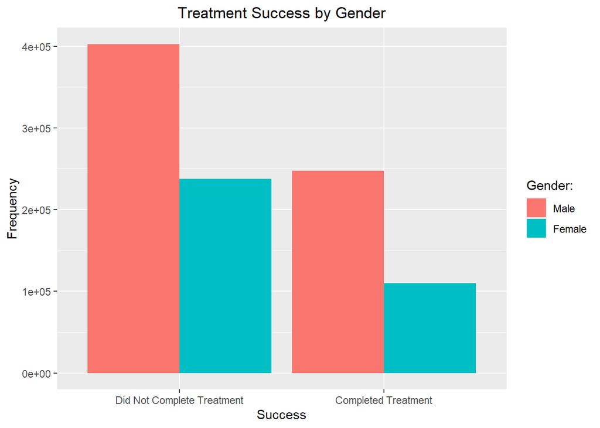

```r
ggplot(teds2, aes(x = SUCCESS, fill = GENDER)) +
  geom_bar(position = "dodge") +
  labs(title = "Treatment Success by Gender", y = "Frequency", x = "Success") +
  theme(plot.title = element_text(hjust=0.5)) +
  scale_fill_discrete(labels=c('Male', 'Female')) +
  scale_x_discrete(labels=c('Did Not Complete Treatment', 'Completed Treatment')) +
  guides(fill = guide_legend(title = "Gender:"))
```

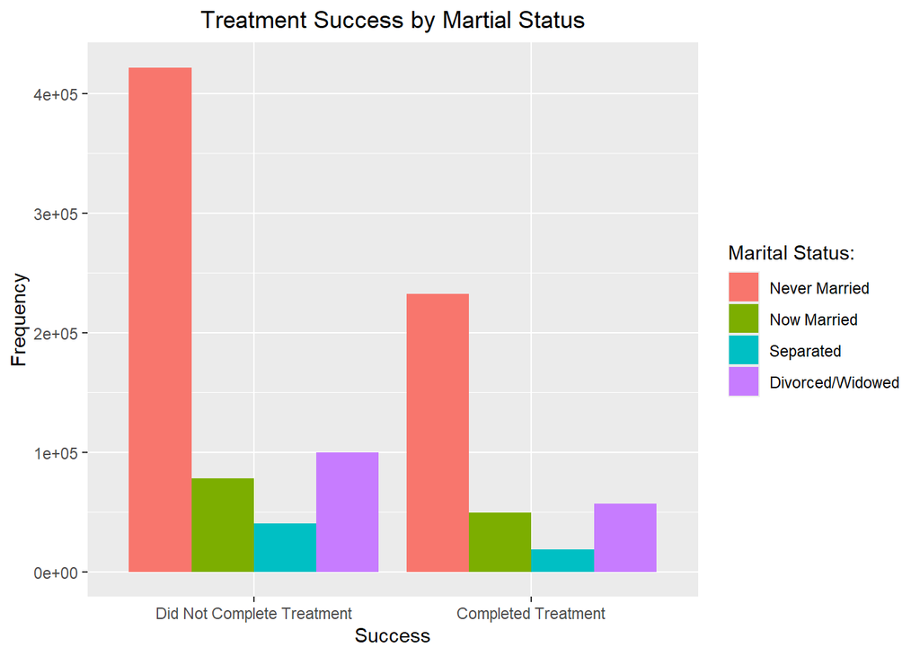

```r
ggplot(teds2, aes(x = SUCCESS, fill = MARSTAT)) +
  geom_bar(position = "dodge") +
  labs(title = "Treatment Success by Martial Status", y = "Frequency", x = "Success") +
  theme(plot.title = element_text(hjust=0.5)) +
  scale_fill_discrete(labels=c('Never Married', 'Now Married', 'Separated', 'Divorced/Widowed', 'NA')) +
  scale_x_discrete(labels=c('Did Not Complete Treatment', 'Completed Treatment')) +
  guides(fill = guide_legend(title = "Marital Status:"))
```

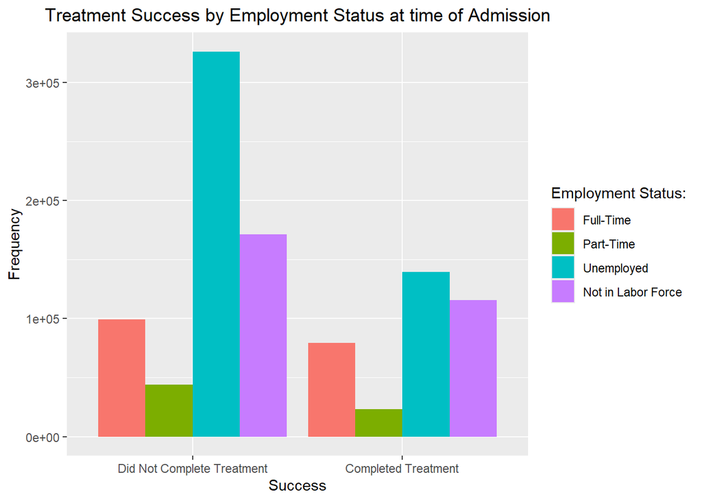

```r
ggplot(teds2, aes(x = SUCCESS, fill = EMPLOY)) +
  geom_bar(position = "dodge") +
  labs(title = "Treatment Success by Employment Status at time of Admission", y = "Frequency", x = "Success") +
  theme(plot.title = element_text(hjust=0.5)) +
  scale_fill_discrete(labels=c('Full-Time', 'Part-Time', 'Unemployed', 'Not in Labor Force', 'NA')) +
  scale_x_discrete(labels=c('Did Not Complete Treatment', 'Completed Treatment')) +
  guides(fill = guide_legend(title = "Employment Status:"))
```

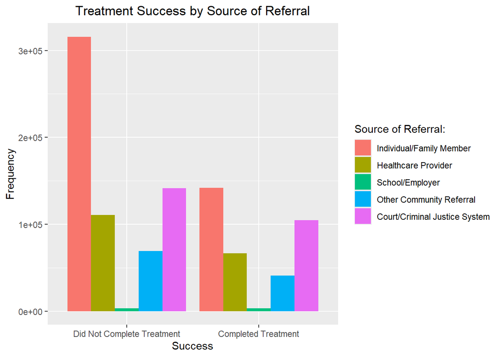

```r
ggplot(teds2, aes(x = SUCCESS, fill = REFERRAL)) +
  geom_bar(position = "dodge") +
  labs(title = "Treatment Success by Source of Referral", y = "Frequency", x = "Success") +
  theme(plot.title = element_text(hjust=0.5)) +
  scale_fill_discrete(labels=c('Individual/Family Member', 'Healthcare Provider', 'School/Employer', 'Other Community Referral', 'Court/Criminal Justice System', 'NA')) +
  scale_x_discrete(labels=c('Did Not Complete Treatment', 'Completed Treatment')) +
  guides(fill = guide_legend(title = "Source of Referral:"))
```

# Binary Logistic Regression assumptions.

1. The observations must be independent. Each observation is a different patient, therefore they are all independent of each other.
2. There must be no perfect multicollinearity among independent variables. I used the vif function after running the regression model to look for multicollinearity; no perfect multicollinearity was found.
3. Continuous predictors are linearly related to a transformed version of the outcome (linearity). I do not have any continuous predictors, therefore this is not applicable to my project.

# Hypothesis Testing

Response variable = SUCCESS Explanatory variable = REFERRAL Control variables = GENDER, MARSTAT, EMPLOY

# Binomial Logistic Regression model - including explanatory variable and all three confounders

# I added the Variance Inflation Factor (vif) function to the first model to look for multicollinearity among the IVs. All values are <2 indicating no multicollinearity concerns.

```r
blr1 <-glm(SUCCESS~REFERRAL+GENDER+MARSTAT+EMPLOY, family=binomial(link = "logit"),data=teds2)
summary(blr1)
```

```
Call:
glm(formula = SUCCESS ~ REFERRAL + GENDER + MARSTAT + EMPLOY,
    family = binomial(link = "logit"), data = teds2)

Deviance Residuals:
    Min       1Q   Median       3Q      Max
-1.3166  -0.9676  -0.8056   1.3221   1.7860

Coefficients:
             Estimate Std. Error z value Pr(>|z|)
(Intercept) -0.416793   0.005926 -70.328   <2e-16 ***
REFERRAL2    0.285542   0.005912  48.300   <2e-16 ***
REFERRAL3    0.646543   0.025052  25.809   <2e-16 ***
REFERRAL4    0.309680   0.007107  43.574   <2e-16 ***
REFERRAL5    0.443130   0.005270  84.089   <2e-16 ***
GENDER2     -0.254475   0.004559 -55.813   <2e-16 ***
MARSTAT2     0.091573   0.006438  14.224   <2e-16 ***
MARSTAT3    -0.154657   0.009377 -16.493   <2e-16 ***
MARSTAT4     0.055154   0.005948   9.273   <2e-16 ***
EMPLOY2     -0.360155   0.009520 -37.831   <2e-16 ***
EMPLOY3     -0.542185   0.005884 -92.141   <2e-16 ***
EMPLOY4     -0.094698   0.006254 -15.141   <2e-16 ***
---
Signif. codes:  0 '***' 0.001 '**' 0.01 '*' 0.05 '.' 0.1 ' ' 1

(Dispersion parameter for binomial family taken to be 1)

    Null deviance: 1301891  on 997850  degrees of freedom
Residual deviance: 1274489  on 997839  degrees of freedom
AIC: 1274513

Number of Fisher Scoring iterations: 4
```

```r
library(car)
vif(blr1)
```

```
             GVIF Df GVIF^(1/(2*Df))
REFERRAL 1.043030  4        1.005280
GENDER   1.026236  1        1.013033
MARSTAT  1.025908  3        1.004272
EMPLOY   1.054796  3        1.008931
```

All predictors are statistically significant in predicting success (completion of treatment) but individual referral does not predict success more than any other type of referral, in fact it has the lowest odds of success among all types of referral (see below).

# Convert coefficients (logits/log odds) to odds ratios by exponentiating the coefficients

```r
exp(coef(blr1))
```

```
(Intercept)   REFERRAL2   REFERRAL3   REFERRAL4   REFERRAL5     GENDER2
  0.6591573   1.3304826   1.9089312   1.3629895   1.5575747   0.7753238
   MARSTAT2    MARSTAT3    MARSTAT4     EMPLOY2     EMPLOY3     EMPLOY4
  1.0958973   0.8567090   1.0567036   0.6975683   0.5814765   0.9096474
```

# Interpretation of odds ratios

People referred by a healthcare provider have 1.33 higher odds of success (completing their treatment program) than those referred by themselves or a family member, keeping other variables constant. In fact all types of referrals have higher odds of success than those referred by themselves or a family member (school/employer: 1.9; other community referral: 1.36; court/criminal justice: 1.56).

Females have .23 lower odds of successfully completing their treatment program than males.

Those that are married and those that were divorced/widowed have higher odds of success (1.1 and 1.06, respectively) than those that have never been married. While those that were separated had .86 lower odds of success than those that have never been married.

Those that had a part-time job, were unemployed, or not in the labor force had lower odds of success (.7, .58, .91, respectively) than those that had a full-time job at the time of admission.

```r
library(ggplot2)
library(dplyr)
library(tidyr)
library(gganimate)
```

## Example 2: Hypothetical Outcome Plot: regression results

# Create new data for hypothetical outcomes

```r
teds3 <- expand.grid(
  REFERRAL = 1:5,
  MARSTAT = 1:4,
  EMPLOY = 1:4,
  GENDER = 1:2
)
teds3
```

```
    REFERRAL MARSTAT EMPLOY GENDER
1          1       1      1      1
2          2       1      1      1
3          3       1      1      1
4          4       1      1      1
5          5       1      1      1
6          1       2      1      1
7          2       2      1      1
8          3       2      1      1
9          4       2      1      1
10         5       2      1      1
11         1       3      1      1
12         2       3      1      1
13         3       3      1      1
14         4       3      1      1
```

[output cut: 146 more lines]

```r
teds3$GENDER <- factor(teds3$GENDER)
teds3$MARSTAT <- factor(teds3$MARSTAT)
teds3$EMPLOY <- factor(teds3$EMPLOY)
teds3$REFERRAL <- factor(teds3$REFERRAL)
str(teds3)
```

```
'data.frame':   160 obs. of  4 variables:
 $ REFERRAL: Factor w/ 5 levels "1","2","3","4",..: 1 2 3 4 5 1 2 3 4 5 ...
 $ MARSTAT : Factor w/ 4 levels "1","2","3","4": 1 1 1 1 1 2 2 2 2 2 ...
 $ EMPLOY  : Factor w/ 4 levels "1","2","3","4": 1 1 1 1 1 1 1 1 1 1 ...
 $ GENDER  : Factor w/ 2 levels "1","2": 1 1 1 1 1 1 1 1 1 1 ...
 - attr(*, "out.attrs")=List of 2
  ..$ dim     : Named int [1:4] 5 4 4 2
  .. ..- attr(*, "names")= chr [1:4] "REFERRAL" "MARSTAT" "EMPLOY" "GENDER"
  ..$ dimnames:List of 4
  .. ..$ REFERRAL: chr [1:5] "REFERRAL=1" "REFERRAL=2" "REFERRAL=3" "REFERRAL=4" ...
  .. ..$ MARSTAT : chr [1:4] "MARSTAT=1" "MARSTAT=2" "MARSTAT=3" "MARSTAT=4"
  .. ..$ EMPLOY  : chr [1:4] "EMPLOY=1" "EMPLOY=2" "EMPLOY=3" "EMPLOY=4"
  .. ..$ GENDER  : chr [1:2] "GENDER=1" "GENDER=2"
```

# Generate predictions with intervals

```r
predictions <- predict(blr1, newdata = teds3, interval = "prediction", level = 0.95)
```

## I tried multiple things below but none of them work

# Combine predictions with new data

hypothetical_data <- teds3 |> mutate(predicted_success = predictions[, “fit”], lower_bound = predictions[, “lwr”], upper_bound = predictions[, “upr”])

# Create the animated plot…still need to update the code below once I get the above code to run.

animated_plot <- ggplot(hypothetical_data, aes(x = size, y = predicted_price, group = rooms, color = as.factor(rooms))) + geom_line(size = 1) + geom_ribbon(aes(ymin = lower_bound, ymax = upper_bound, fill = as.factor(rooms)), alpha = 0.2) + labs(title = ‘Hypothetical Outcome Plot: Housing Price vs. Size (Urban)’, subtitle = ‘Number of Rooms: {closest_state}’, x = ‘Size (sq ft)’, y = ‘Predicted Price ($)’, color = ‘Number of Rooms’, fill = ‘Number of Rooms’) + theme_minimal() + transition_states(rooms, transition_length = 2, state_length = 1) + ease_aes(‘linear’)

# Render the animation

animate(animated_plot, nframes = 100, fps = 10)

# Tried the following that I found online

set.seed(016752277)

predictions <- predict(blr1, newdata = teds4, type = “response”) hypothetical_data <- teds4 |> mutate(predicted_success = predictions[, “fit”], lower_bound = predictions[, “lwr”], upper_bound = predictions[, “upr”])

## Also tried your 1st Example: Hypothetical Outcome Plot: descriptive statistics

set.seed(01002) # For reproducibility n_simulations <- 1000 # Number of hypothetical outcomes

# Create a data frame with simulated outcomes for each Type

simulated_data <- teds5 |> rowwise() |> do(data.frame(REFERRAL = .$REFERRAL, outcome = rnorm(n_simulations, n = .$n), sim_id = 1:n_simulations))